# STAT-431 HW 1

## Lab 1: Review of Statistical Computing with R

### Part One: Checking Normality (150 pts)

In this section, you will use a Q-Q Plot to check if a vector of values x comes from a Normal distribution. The approach is to randomly generate a new vector y from a Normal distribution with the same mean and standard deviation as x, then to create a Q-Q plot of x and y. (Note: A typical Normal Q-Q plot uses theoretical quantiles instead of randomly generated values. We’re taking a bit of a shortcut in this assignment.)

Your final function should take as input a numeric vector.

It should return (not just print!) a Q-Q Plot comparing your input to Normally distributed values.

You may not use any existing functions specific to Q-Q plots; including (but not limited to) qqplot(), geom_qq, or stat_qq.

Demonstrate that your function works by running it on either real data of your choice, or on a non-Normal vector that you create.

```r
qqplot <- function(x){
  # Generate normal vector y
  y <- rnorm(length(x), mean = mean(x), sd = sd(x))

  # Get Proper Order of x, y
  x_order <- order(x)
  y_order <- order(y)

  # Use Above to Order X, Y
  ordered_x <- x[x_order]
  ordered_y <- y[y_order]

  # Create Plot
  p <- plot(ordered_x, ordered_y, xlab = 'x', ylab = 'y', main = 'QQPlot')
  return(p)
}
```

I test the plot above with one normal vector and another non-normal vector:

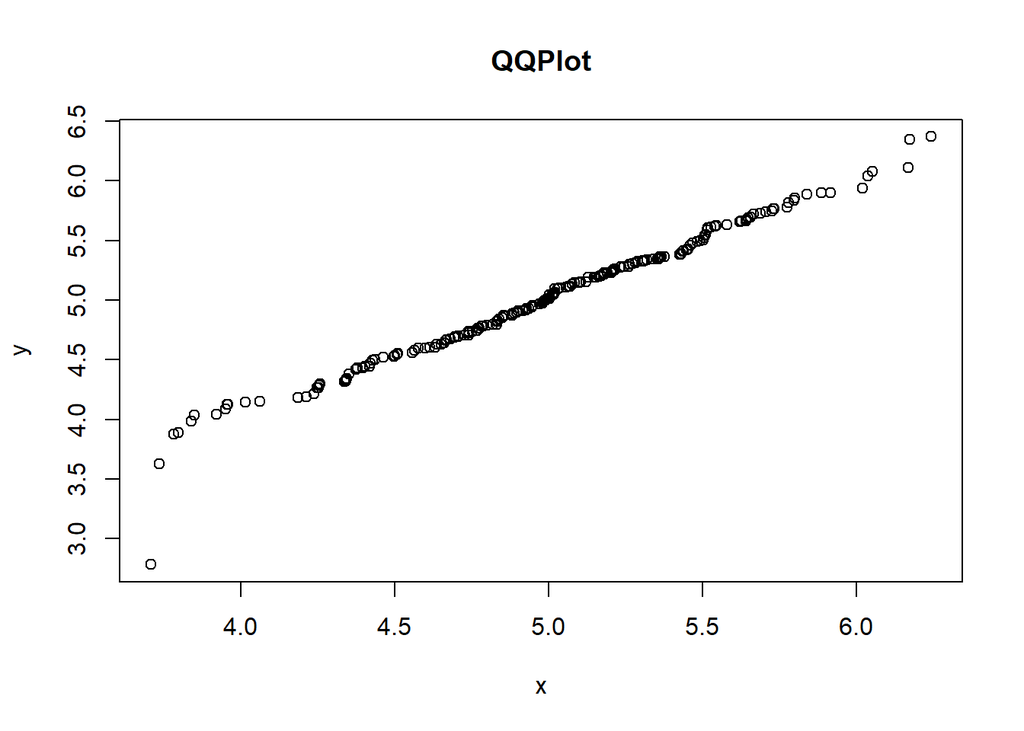

```r
x <- rnorm(200, 5, 0.5)
qqplot(x)
```

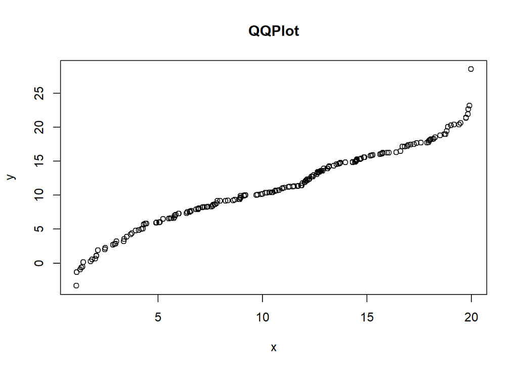

```r
x <- sample(seq(1, 20, 0.001), 200, replace = T)
qqplot(x)
```

### Part Two: Data Analysis (150 points)

Use the dataset `Oscars-demographics-DFE.csv` in this repository.

```r
oscars <- read_csv('https://raw.githubusercontent.com/Cal-Poly-Advanced-R/Lab_1/master/Oscars-demographics-DFE.csv')
```

In what follows, the phrase “Big 5 Awards” refers to the five individual Academy Awards covered in this dataset: Best Director, Best Actor, Best Actress, Best Supporting Actor, and Best Supporting Actress.

#### Warm-ups (10 points each)

Which movie(s) won the most unique “Big 5” awards?

```r
oscars %>%
  distinct(movie, award, year_of_award) %>% #unique movie-year-award
  group_by(movie) %>%
  count() %>%
  arrange(desc(n)) %>%
  ungroup() %>%
  top_n(1)
```

```
## # A tibble: 1 x 2
##   movie               n
##   <chr>           <int>
## 1 West Side Story     4
```

Of all actresses who have won the Best Actress award, what are is the most common first name?

```r
oscars %>%
  filter(award == 'Best Actress') %>% #won the award for Best Actress
  distinct(person) %>% #unique best-actress
  mutate(first_name = str_split(person, ' ') %>% map(1) %>% unlist()) %>% #get first name
  group_by(first_name) %>%
  count() %>%
  arrange(desc(n)) %>%
  head()
```

```
## # A tibble: 6 x 2
## # Groups:   first_name [6]
##   first_name     n
##   <chr>      <int>
## 1 Helen          3
## 2 Jane           2
## 3 Jennifer       2
## 4 Jessica        2
## 5 Joan           2
## 6 Julie          2
```

What US State, or non-US country, has produced the most Oscar winners (for the awards in this dataset)?

```r
oscars %>%
  filter(!is.na(birthplace)) %>%
  mutate(
    birthplace = if_else(birthplace == 'New York City', 'Ny', birthplace),
    birthplace = birthplace %>% str_split(', ') %>% map(last) %>% unlist()
         ) %>% #get first name
  distinct(birthplace, year_of_award) %>%
  group_by(birthplace) %>%
  count() %>%
  arrange(desc(n))
```

```
## # A tibble: 67 x 2
## # Groups:   birthplace [67]
##    birthplace     n
##    <chr>      <int>
##  1 Ny            42
##  2 England       38
##  3 Ca            36
##  4 Il            18
##  5 Ma            11
##  6 Nj            11
##  7 Mo            10
##  8 Pa            10
##  9 Oh             9
## 10 France         8
## # ... with 57 more rows
```

It seems like New York has the most Oscar winners.

#### Age and Gender (60 points)

The information in this dataset includes two awards given only to women (Best Actress, Best Supporting Actress) and two awards given only to men (Best Actor, Best Supporting Actor).

Create a linear model that explores how the typical age of acting award winners has changed over time, and how that effect is different for the two genders of awards.

```r
reg_df <- oscars %>%
  filter(award %in% c('Best Actress', 'Best Supporting Actress', 'Best Actor', 'Best Supporting Actor')) %>%
  mutate(gender = if_else(award %in% c('Best Actress', 'Best Supporting Actress'), 'F', 'M'),
         age = as.numeric(str_extract(date_of_birth, '....$')),
         age = year_of_award - age) %>%
    select(date_of_birth, race_ethnicity, year_of_award, award, gender, age)
reg <- lm(age ~ award + race_ethnicity + age*gender*year_of_award, data = reg_df)
summary(reg)
```

```
##
## Call:
## lm(formula = age ~ award + race_ethnicity + age * gender * year_of_award,
##     data = reg_df)
##
## Residuals:
##     Min      1Q  Median      3Q     Max
## -0.1066  0.0000  0.0000  0.0000  0.1698
##
## Coefficients: (1 not defined because of singularities)
##                                Estimate Std. Error t value Pr(>|t|)
## (Intercept)                   7.082e-03  6.012e+00   0.001    0.999
## awardBest Actress             6.841e+01  6.521e+00  10.492 8.66e-14 ***
## awardBest Supporting Actor    1.697e-14  1.652e-02   0.000    1.000
## awardBest Supporting Actress  6.849e+01  6.524e+00  10.499 8.46e-14 ***
## race_ethnicityWhite          -7.082e-03  4.515e-02  -0.157    0.876
## genderM                              NA         NA      NA       NA
## year_of_award                -3.533e-02  1.320e-03 -26.758  < 2e-16 ***
## age:genderM                   1.000e+00  8.886e-02  11.253 8.35e-15 ***
## age:year_of_award             5.159e-04  5.474e-07 942.467  < 2e-16 ***
## genderM:year_of_award         3.533e-02  3.367e-03  10.492 8.64e-14 ***
## age:genderM:year_of_award    -5.159e-04  4.569e-05 -11.292 7.43e-15 ***
## ---
## Signif. codes:  0 '***' 0.001 '**' 0.01 '*' 0.05 '.' 0.1 ' ' 1
##
## Residual standard error: 0.04252 on 46 degrees of freedom
##   (294 observations deleted due to missingness)
## Multiple R-squared:      1,  Adjusted R-squared:      1
## F-statistic: 5.532e+05 on 9 and 46 DF,  p-value: < 2.2e-16
```

Overall, there is a positive relationship between age, time, and the likelihood of winning an award. This effect is *stronger* for men. However, the strenght of this effect has decreased over time.

#### Bootstrapping (60 points)

Use a bootstrap approach to answer the following question: What is an approximate 95% confidence interval for percent of “Big 5 Award” award winners who are not white?

```r
# Get Race
race <- oscars$race_ethnicity

# Code Race as White / Non White
race[race == 'White'] <- 0
race[race != 0] <- 1
race <- as.numeric(race)

# Bootstrap
n <- 1000 #number of times to repeat
per_nonwhite <- rep(NA, n)

for (i in c(1:1000)){
  new_sample <- sample(race, length(race), replace = T)
  per_nonwhite[i] <- mean(new_sample)
}

bootstrapped_ci <- data.frame(
  'bottom_range' = quantile(per_nonwhite, 0.025),
  'top_range' = quantile(per_nonwhite, 0.975),
  'median_range' = median(per_nonwhite)
)

bootstrapped_ci
```

```
##      bottom_range top_range median_range
## 2.5%   0.04535147 0.0952381   0.06802721
```

In addition to the confidence interval, make a plot that illustrates your findings.

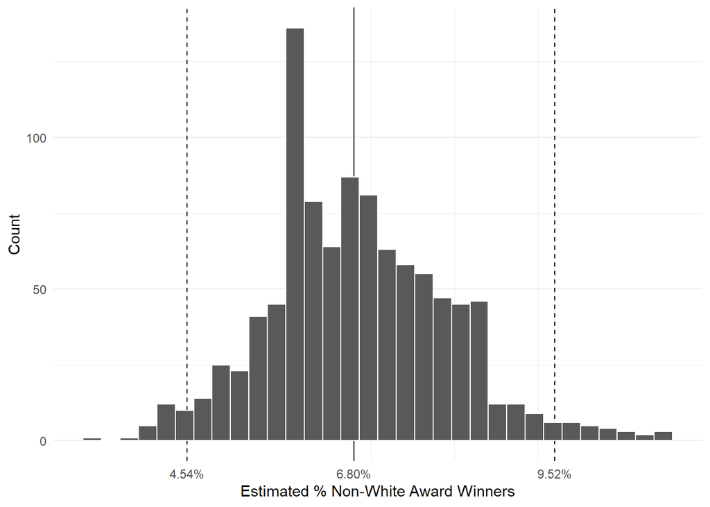

```r
graph_breaks <- c(bootstrapped_ci$bottom_range, bootstrapped_ci$top_range, bootstrapped_ci$median_range)

data.frame('per_nonwhite' = per_nonwhite ) %>%
  ggplot(aes(per_nonwhite)) +
  geom_vline(aes(xintercept = quantile(per_nonwhite, 0.025)), linetype = 'dashed') +
  geom_vline(aes(xintercept = quantile(per_nonwhite, 0.975)), linetype = 'dashed') +
  geom_vline(aes(xintercept = median(per_nonwhite))) +
  geom_histogram(binwidth = 0.0025, color = 'white') +
  scale_x_continuous(labels = percent, breaks = graph_breaks) +
  labs(x = 'Estimated % Non-White Award Winners', y = 'Count') +
  theme_minimal()
```